# Bayesian Linear Regression

Literature Review

Heather Anderson, Sara Parrish (Advisor: Dr. Seals)

Oct 3, 2024

# Introduction to Bayesian Linear Regression

- Regression under the *frequentist* framework
  - Independent variables are used to predict dependent variables
  - Linear regression finds best-fitting line to observed data to make further predictions
    - Regression parameters ($\beta$) are assumed to be fixed
  - Only collected data is used for approximation
- Regression under the *Bayesian* framework
  - Independent variables are used to predict dependent variables
  - Regression parameters ($\beta$) *are not* assumed to be fixed
  - Collected data is used alongside prior knowledge for approximation

## Frequentist vs. Bayesian Approach

- **Frequentist** Approach
  - Typical linear model

$$Y = \beta_0 + \beta_1X + \varepsilon \tag{1}$$

- $Y$ : Dependent variable, the outcome
- $\beta_0$ : y intercept
- $\beta_1$ : The regression coefficient
- $X$ : Independent variable
- $\varepsilon$ : Random error [1]
- $\hat\beta$ provides a point estimate

## Frequentist vs. Bayesian Approach

- **Bayesian** Approach
  - A regression is constructed using probability distributions, not point estimates as in the frequentist approach
  - Bayes Rule (2) is used to inform the model [1]

$$p(B|A) = \frac{p(A|B)\cdot p(B)}{p(A)} \tag{2}$$

- Bayes Rule allows for the calculation of inverse probability ($p(B|A) \text{ from } p(A|B)$)
- $p(B|A) \text{ and } p(A|B)$ are conditional probabilities
- $p(A) \text{ and } p(B)$ are marginal probabilities [2]

## Frequentist vs. Bayesian Approach

- **Bayesian** Approach
  - Bayesian Inference can be written simply [3]

$$Posterior = \frac{Likelihood \times Prior}{Normalization}$$

- The $Prior$ is model of prior knowledge on the subject
- The $Likelihood$ is the probability of the data given the prior
- The $Normalization$ is a constant that ensures the posterior distribution is a valid density function whose integration is equal to 1
- The $Posterior$ is the probability model that expresses an updated view of the model parameters
  - From the initial parameters of the prior
  - Updated with new data expressed in the likelihood function

## Frequentist vs. Bayesian Approach

- **Bayesian** Approach
  - A more formal expression of Bayes Rule applied for continous parameters

$$\begin{align*}
p(\theta|y) =& \frac{ L(\theta|y)p(\theta) }{p(y)}\\
\\
p(\theta|y) \propto & \text{ }L(\theta|y)p(\theta)
\end{align*}$$

- The normalization constant ($p(y)$ above) ensures the posterior distribution is a valid distribution
  - The posterior density function can be written without this constant
- The resulting prediction is not a point estimate, but a distribution [4]

## Role of prior knowledge in shaping predictions

- Priors can be subjective or objective
  - objective is preferred
- Noninformative priors can be used when there is not adequate prior knowledge
- Discounted priors are the result of adjusting a known prior to better reflect the current data[2]

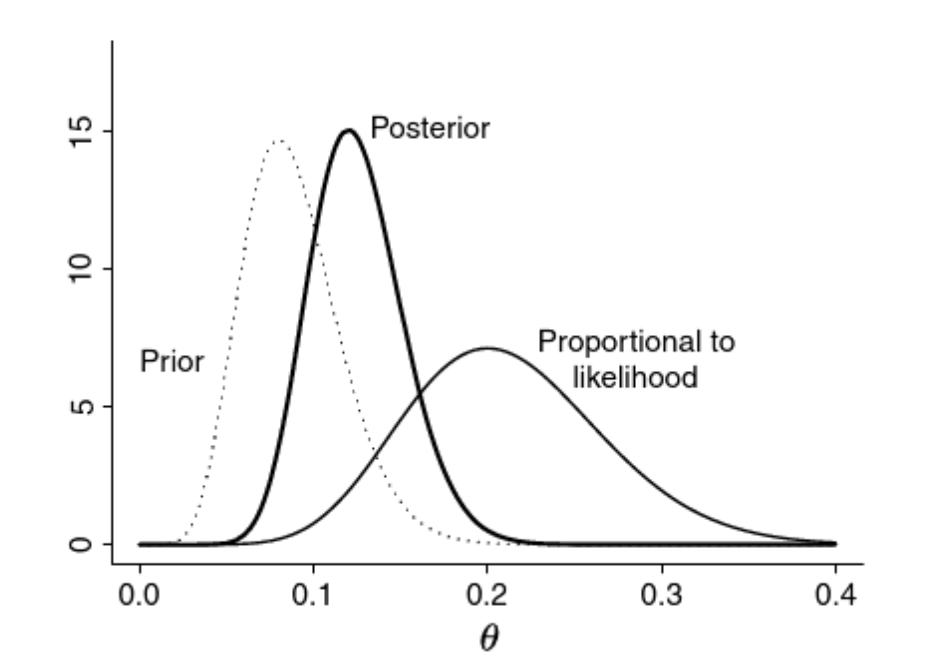

Figure from [2]

# Understanding the Bayesian Framework

- Bayes’ theorem is used to update prior beliefs about model parameters with new data
  - This results in a posterior distribution [4]
- Posterior distribution vs. point estimates
  - measures the uncertainty in predictions
  - richer picture for predictions
  - better uncertainty quantification [3]

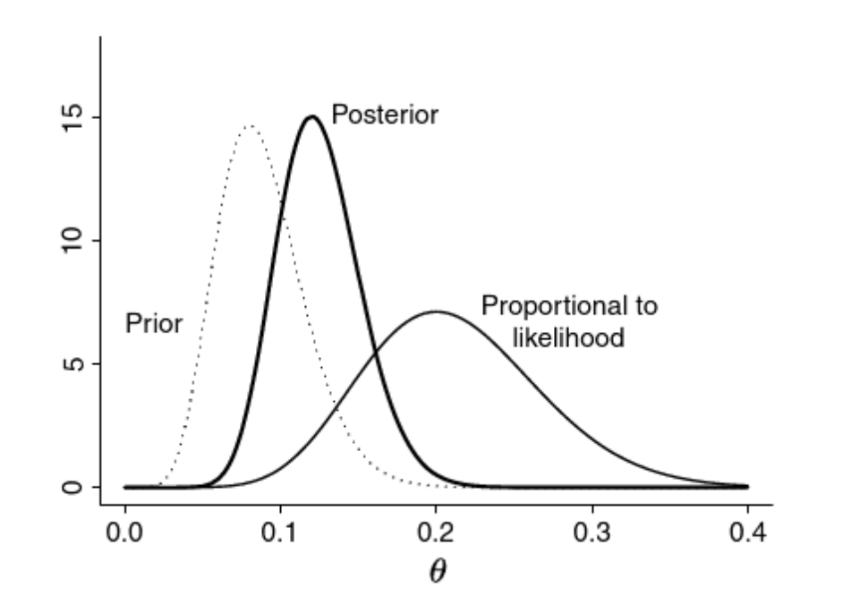

Figure from [2]

## Interpreting the Posterior

- The marginal posterior density function (output) may not be available
- Makov Chain Monte Carlo is commonly used
  - Markov chain sequence establishes a sample space from the posterior
  - Integration of samples generated through Monte Carlo techniques from the sample space
- Some popular MCMC algorithms:
  - Gibbs sampler
  - Metropolis-Hastings (MH) [2]

# Tools and Techniques in Bayesian Analysis

[figure not shown]

BAT logo (https://bat.mpp.mpg.de/?page=home)

- The Bayesian Analysis Toolkit (BAT)
  - real-world application of Bayesian methods
  - Markov Chain Monte Carlo (MCMC) for sampling and model comparison[5]
  - Visualization tools (trace plots, HMC diagnostics) for model assessment [6]

# Advantages of Bayesian Methods

**Note**

- Findings from Zyphur and Oswald on reliability
  - Bayesian methods are more reliable with small samples
  - Better predictions and understanding of data [7]
- Better analysis of complex data due to advancements in computational power
  - e.g. autoencoders [8]
- Interpretation of posteriors
  - commonly done with MCMC
  - variational inference has been offered as an alternative [9]

# Conclusion and Future Directions

- Key strengths of BLR
  - flexibility
  - uncertainty management
- Exploration of MCMC and foundational Bayesian principles
- Potential for future applications in complex data analysis

# Further Research

**Modifications to BLR**

- Kernalization (with Gaussian kernel) and Sparsification[10]
- Warping to handle non-linear trends [11]
- BLR in concert with k-means clustering to creat subdivisions of the population [12]
- Use with Cauchy prior to improve performance with sparse array input [13]
- Gridded BLR by means of producing a model grid to predict storm winds [14]

## References

[1]

X. Yan and X. G. Su, *Linear regression analysis: Theory and computing*. Singapore: World Scientific Publishing, 2009. Available: https://ebookcentral.proquest.com/lib/uwf/reader.action?docID=477274&ppg=318&pq-origsite=primo

[2]

E. Lesaffre and A. B. Lawson, *Bayesian biostatistics*, 1st ed. Somerset: John Wiley & Sons, Ltd, 2012. doi: https://doi.org/10.1002/9781119942412.

[3]

W. Koehrsen, “Introduction to bayesian linear regression.” https://towardsdatascience.com/introduction-to-bayesian-linear-regression-e66e60791ea7, Apr. 2018.

[4]

T. Bayes, “An essay towards solving a problem in the doctrine of chances. 1763,” 1763.

[5]

A. Caldwell, D. Kollár, and K. Kröninger, “BAT – the bayesian analysis toolkit,” *Comput. Phys. Commun.*, vol. 180, no. 11, pp. 2197–2209, Nov. 2009.

[6]

J. Gabry, D. Simpson, A. Vehtari, M. Betancourt, and A. Gelman, “Visualization in bayesian workflow,” *J. R. Stat. Soc. Ser. A Stat. Soc.*, vol. 182, no. 2, pp. 389–402, Feb. 2019.

[7]

M. J. Zyphur and F. L. Oswald, “Bayesian estimation and inference,” *J. Manage.*, vol. 41, no. 2, pp. 390–420, Feb. 2015.

[8]

R. van de Schoot *et al.*, “Bayesian statistics and modelling,” *Nat. Rev. Methods Primers*, vol. 1, no. 1, Jan. 2021.

[9]

D. M. Blei, A. Kucukelbir, and J. D. McAuliffe, “Variational inference: A review for statisticians,” *J. Am. Stat. Assoc.*, vol. 112, no. 518, pp. 859–877, Apr. 2017.

[10]

D. Kong, J. Zhu, C. Duan, L. Lu, and D. Chen, “Bayesian linear regression for surface roughness prediction,” *Mechanical Systems and Signal Processing*, vol. 142, p. 106770, 2020, doi: https://doi.org/10.1016/j.ymssp.2020.106770.

[11]

C. J. Fraza, R. Dinga, C. F. Beckmann, and A. F. Marquand, “Warped bayesian linear regression for normative modelling of big data,” *NeuroImage*, vol. 245, p. 118715, 2021, doi: https://doi.org/10.1016/j.neuroimage.2021.118715.

[12]

X. Zhang, Y. Ding, H. Zhao, and L. Yi, “Long‐term bridge performance assessment using clustering and bayesian linear regression for vehicle load and strain mapping model,” *Struct. Contr. Health Monit.*, vol. 29, no. 12, Dec. 2022, doi: https://doi.org/10.1016/j.ymssp.2020.106770.

[13]

J. Li, R. Wu, I.-T. Lu, and D. Ren, “Bayesian linear regression with cauchy prior and its application in sparse MIMO radar,” *IEEE Trans. Aerosp. Electron. Syst.*, vol. 59, no. 6, pp. 9576–9597, Dec. 2023, doi: https://doi.org/10.1109/TAES.2023.3321585.

[14]

J. Yang, M. Astitha, and C. S. Schwartz, “Assessment of storm wind speed prediction using gridded bayesian regression applied to historical events with NCAR’s real‐time ensemble forecast system,” *J. Geophys. Res.*, vol. 124, no. 16, pp. 9241–9261, Aug. 2019, doi: https://doi.org/10.1029/2018JD029590.